# Bar charts - diamonds

The alternative options for position are “identity”,“dodge” and “fill”.

1. Produce additional plots using these position options. How do they differ?
2. Can you think of cirumstances under which you would have a preference for different uses of ‘position’?

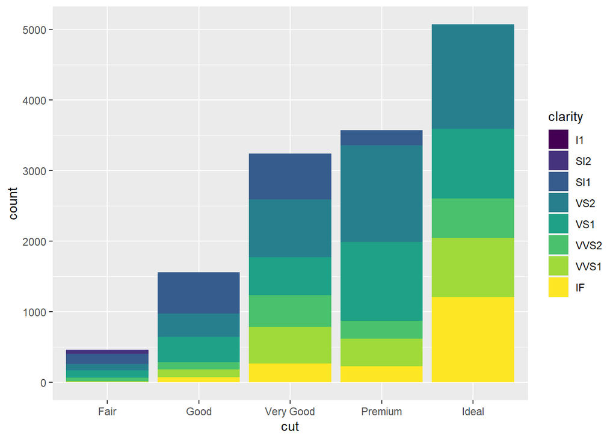

```r
# Add your code here
# Position = identity
plot9 <- ggplot(data = diamonds) +
  geom_bar(mapping=aes(x=cut,fill=clarity),position="identity")
plot9
```

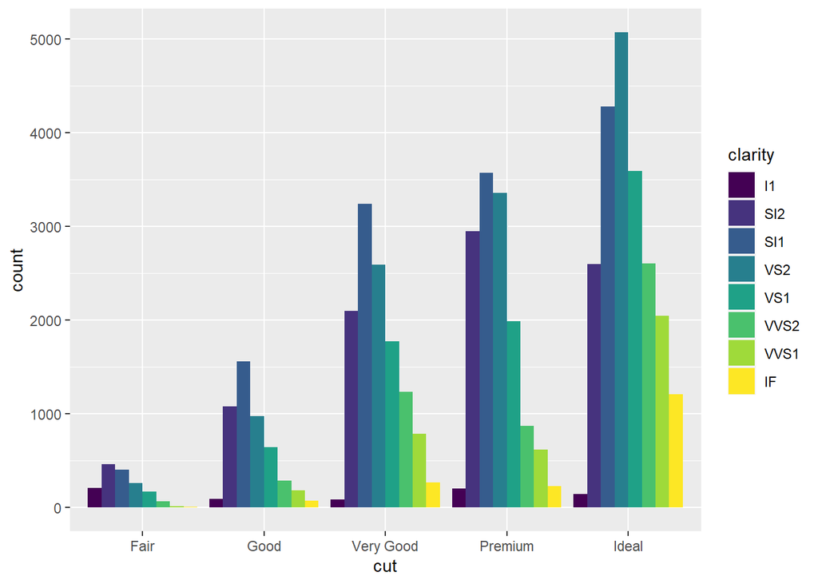

```r
# similar to stack
# Position = dodge
plot10 <- ggplot(data = diamonds) +
  geom_bar(mapping=aes(x=cut,fill=clarity),position="dodge")
plot10
```

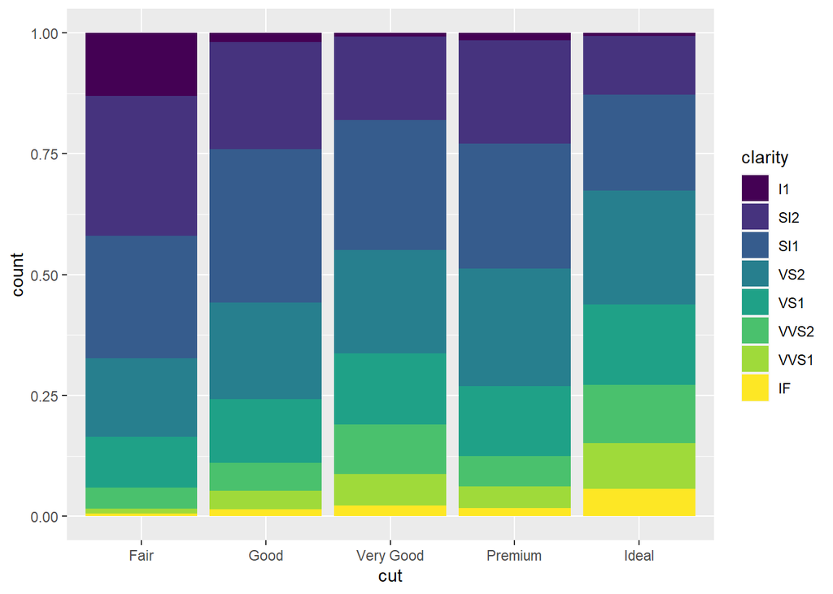

```r
# can be used to compare distribution amongst different levels
# Position = fill
plot11 <- ggplot(data = diamonds) +
  geom_bar(mapping=aes(x=cut,fill=clarity),position="fill")
plot11
```

```r
# can be used to compare proportions in sets, not specifically on quantity
```

## Finally…

Finally, we can alter the coordinate system with some simple functions.

- coord_flip() swaps the x and y coordinates
- coord_polar() uses polar coordinates

We can add these functions as another layer to our ggplot command.

For example we could say:

```
ggplot(data=diamonds) +
   geom_bar(mapping=aes(x=cut,fill=cut)) +
   coord_flip()
```

If we have an existing object produced by ggplot, we could say:

```
plot4 + coord_flip()
```

### Task

Using plot4

1. Add coord_flip() as an option
2. Add coord_polar() as an option

Next, try doing the same, but with one of the plots that use x=cut and fill=clarity.

3. What happens to this in a polar plot?
4. What happens with different settings for position?

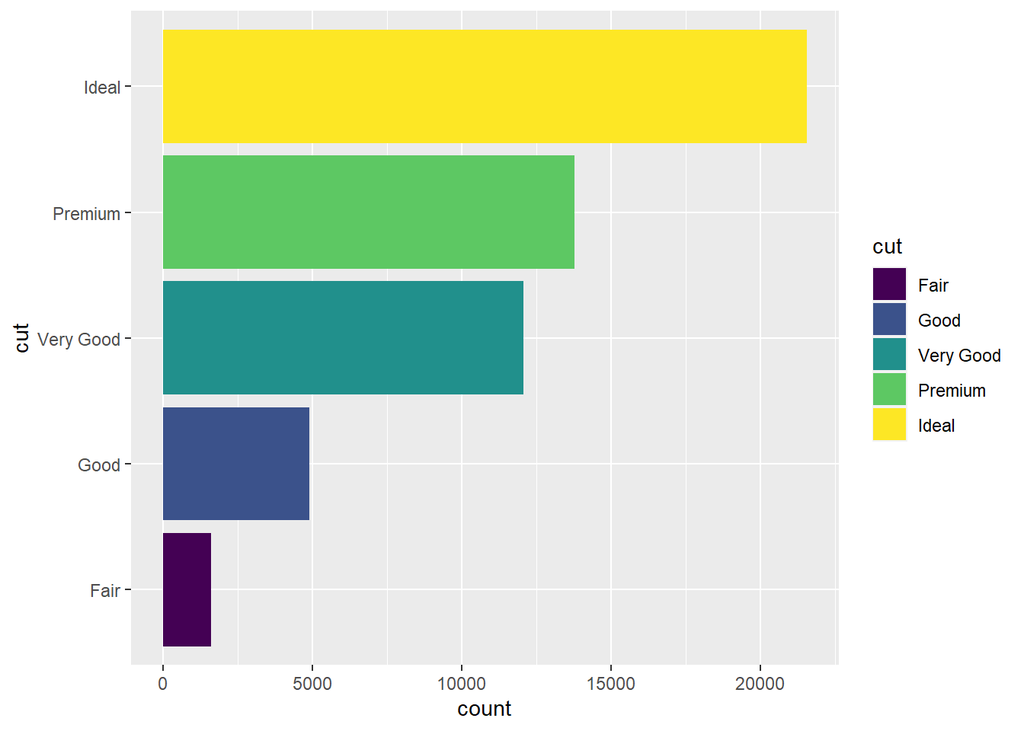

```r
# Add R code here
p41 <- plot4 + coord_flip()
p41
```

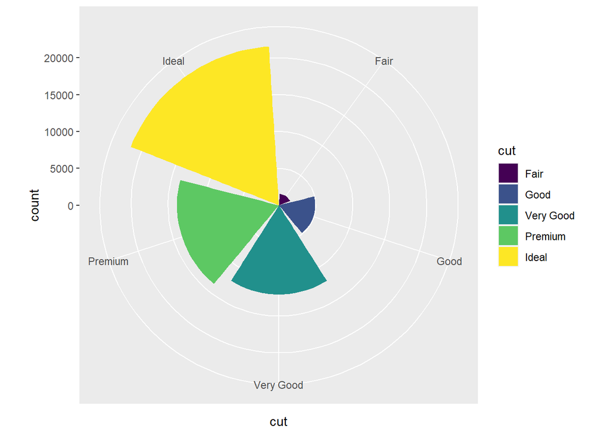

```r
p42 <- plot4 + coord_polar()
p42
```

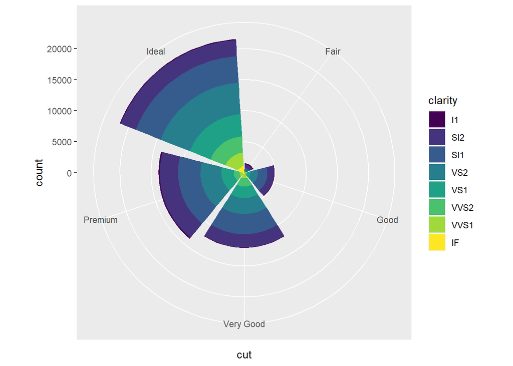

```r
p43 <- plot7 + coord_polar()
p43
```

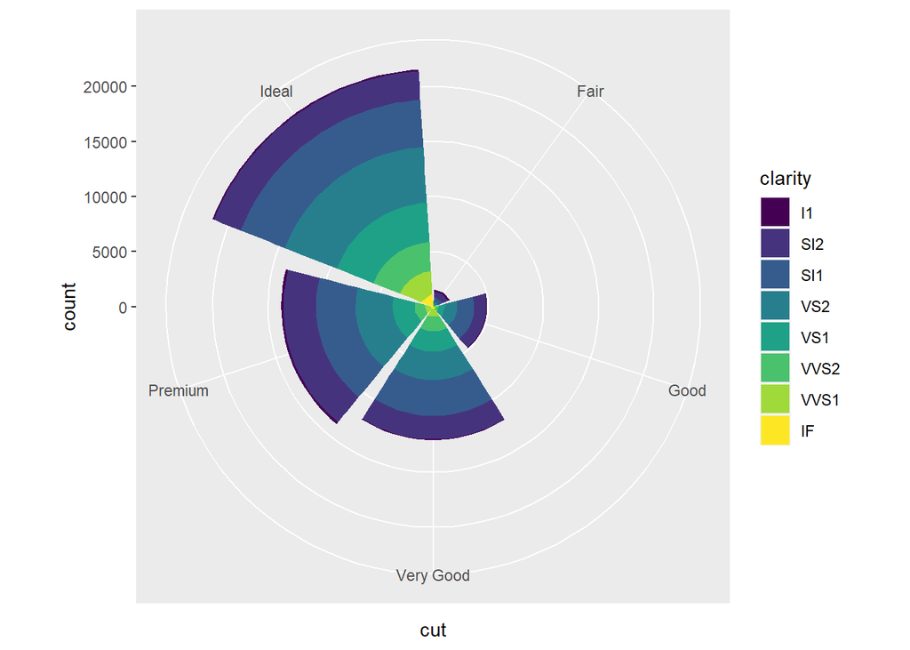

```r
p441 <- plot8 + coord_polar()
p441
```

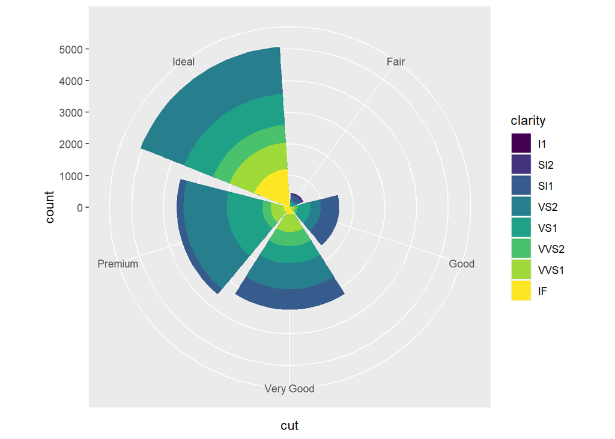

```r
p442 <- plot9 + coord_polar()
p442
```

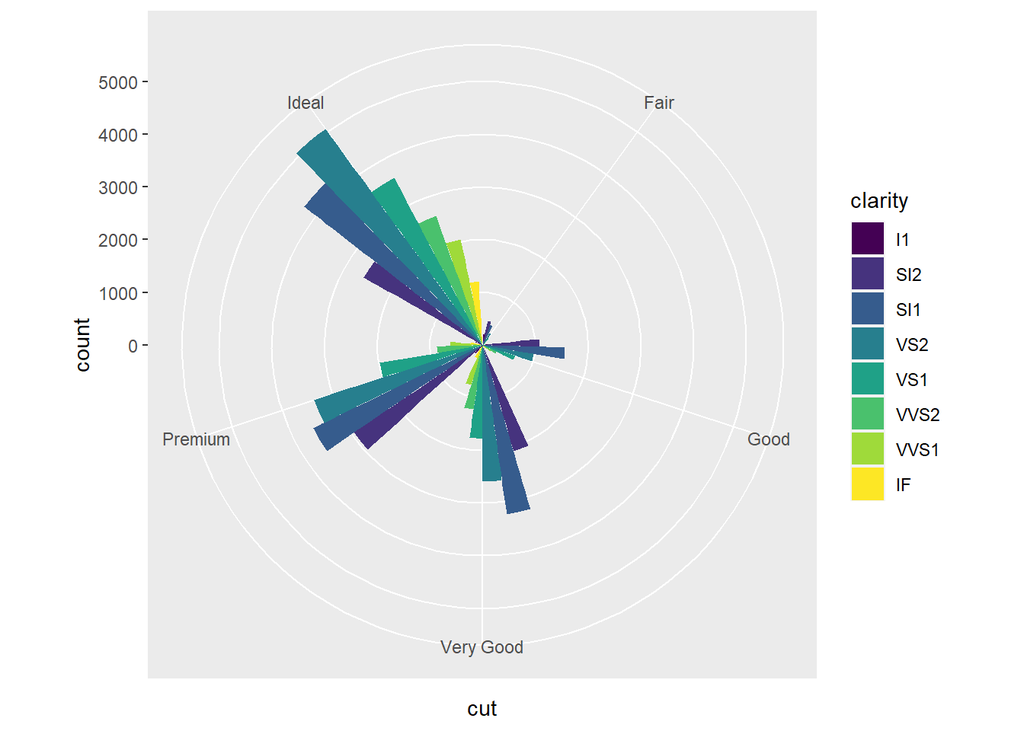

```r
p443 <- plot10 + coord_polar()
p443
```

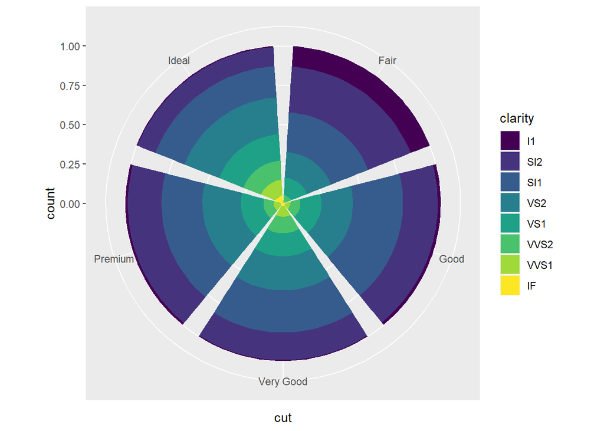

```r
p444 <- plot11 + coord_polar()
p444
```